# Yang_assignment

```python
from IPython import display
```

```python
OVG=display.IFrame('notebook_material/Mutation_in_genes_overlap.pdf',width=400,height=400)
OVM=display.IFrame('notebook_material/Mutation_overlap.pdf',width=400,height=400)
MR_p=display.IFrame('notebook_material/Mutations_rate.pdf',width=600,height=600)
CosM_dis=display.IFrame('notebook_material/CosM.mutations.pdf',width=800,height=800)
MutSig_dis=display.IFrame('notebook_material/MSigCV.mutations.pdf',width=800,height=800)
OVMut_dis=display.IFrame('notebook_material/OV5M.mutations.pdf',width=800,height=800)
COR=display.IFrame('notebook_material/test_correlation.pdf',width=800,height=800)
CRC_cellline=display.Image("notebook_material/CRC_cellline.jpg")
CRC_mmG=display.Image("notebook_material/CRC_mutated_genes.png")
Mutatation_on_CRC_mmG=display.IFrame("notebook_material/Mutations_distribution_on_reported_FF_genes.pdf",width=800,height=800)
Mutatation_genes=display.IFrame("notebook_material/Number_of_mutation_in_genes.pdf",width=600,height=400)
Mutation_type=display.Image("notebook_material/Mutation_classification.png")
```

#### Note:

A assignment from Prof.Yang

## About the assignment

**1.About data**:

a. Somatic mutations from 5 colon cancer patients. (primary tumor tissues, blood collected to remove germline SNP).

b.The file format is chr, pos, reference allele, alternative allele, sample ID(reference hg19).

c.whole genome sequenced by Illumina (50x coverage) (PE 2X100bp).

d.Mutations were called by MuTect and VarScan. Blood was used to filter germline variants.

**2. Question**

a.Pick 4 different genomic features and GC content, and test correlations of the features and the mutation density. Describe what features you select, where you download the data associated to the features (provide links), how you test for correlations, report the P values and what conclusions you can draw from the results.

b.Sequencing and mutation calling can be of poor quality. How would you figure out whether the biases you identified are biological or technical artifacts? **Assuming you have access to the raw sequencing files, write down how would you use the raw data to answer the questions.**

## Backgroud about colorectal cancer(CRC)

[CRC](https://portal.gdc.cancer.gov/exploration?filters=~%28op~%27and~content~%28~%28op~%27in~content~%28field~%27cases.primary_site~value~%28~%27Colorectal%29%29%29%29%29&searchTableTab=genes)

- **[Most Frequently Mutated Genes](https://portal.gdc.cancer.gov/exploration?filters=~%28op~%27and~content~%28~%28op~%27in~content~%28field~%27cases.primary_site~value~%28~%27Colorectal%29%29%29%29%29&searchTableTab=genes)**

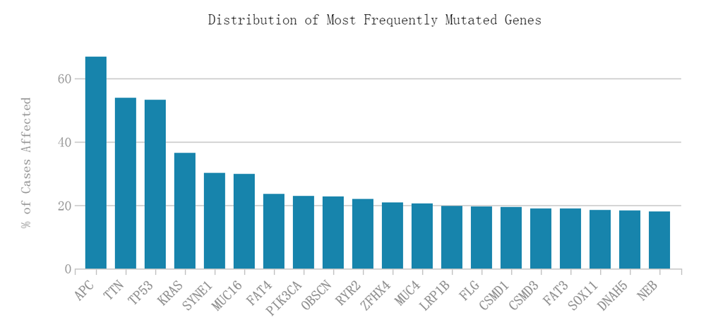

```python
CRC_mmG
```

- **[Colon cancer cell line origins](https://www.ncbi.nlm.nih.gov/pmc/articles/PMC3816225/)**

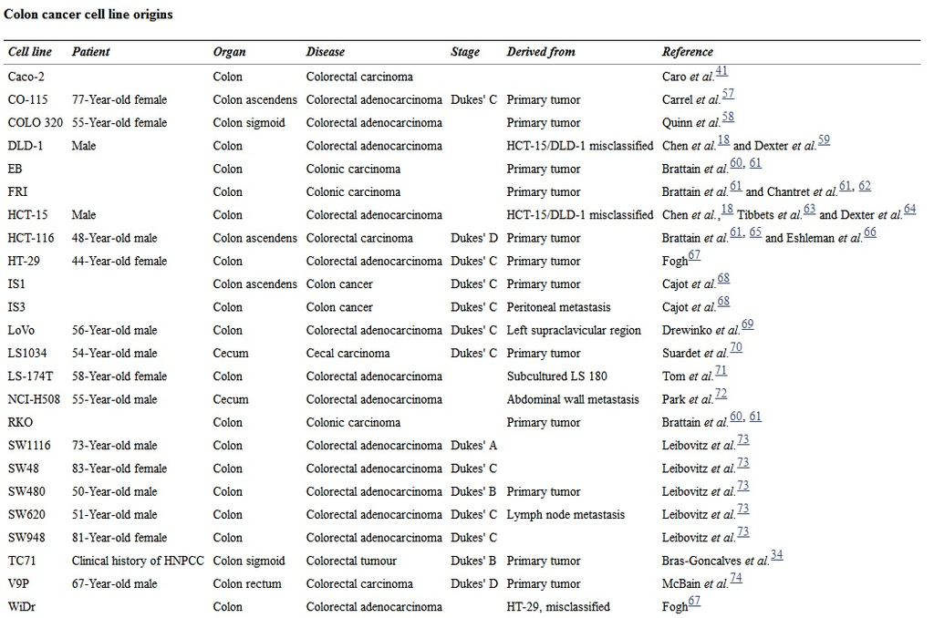

```python
CRC_cellline
```

## Answers:

**I assumed I got the raw data and did the following analysis to answer the question**

### 1. Analysis of raw data

Analysis pipeline [Ref:Comprehensive Molecular Characterization of Urothelial Bladder Carcinoma](https://www.ncbi.nlm.nih.gov/pmc/articles/PMC3962515/))

#### 1.1 DNA Sequencing analysis

(1)Quality control of raw data

(2)Mapping raw reads to GRCh37 by BWA

(3)Picard used to make a single bam stores all reads and calibrated qualities along with their alignments to the genome

(4)Variant calling and remove library preparation artifact

Several pipeline is provided such as [Firehose](https://gdac.broadinstitute.org/). Firehose include following steps:

1. Quality control – confirms identity of individual tumor and normal to avoid mix-ups between tumor and normal data for the same individual.
2. Local realignment of reads – realigns sites potentially harboring small insertions or deletions in either the tumor or the matched normal to decrease the number of false positive single nucleotide variations caused by misaligned reads.
3. Identification of somatic single nucleotide variations (SSNVs) – Mutect algorithm – candidate SSNVs were detected using a statistical analysis of the bases and qualities in the tumor and normal BAMs.
4. Identification of somatic small insertions and deletions – Indelocator algorithm – putative somatic events were first identified within the tumor BAM file and then filtered out using the corresponding normal data.

#### 1.2 Mutation significance analysis

The statistical significance of mutation frequency in each gene was determined using the algorithm [MutSig](http://archive.broadinstitute.org/cancer/cga/mutsig). Use qvalue as cutoff and (AF) >= 0.05 to remove potential subclonal mutations. Include genes significantly mutated genes from [COSMIC](http://cancer.sanger.ac.uk/cosmic) database

#### 1.3 How to improve accuracy of analysis.

From the [Ref:A comprehensive assessment of somatic mutation detection in cancer using whole-genome sequencing](https://www.ncbi.nlm.nih.gov/pubmed/?term=26647970)

We should know:

- About the library depth(a minimum of 30 × sequence coverage, 100 X sequence coverage would be the best)
- Effect of tumor purity on mutation calling.(no more than 17% 'contamination' of normal samples in tumour would be great)
- Effect of tumor to normal sequencing depth ratio(Increasing depth of normal samples is help to decrease the false positive)
- Effect of somatic mutation calling pipelines. MB.Q and MB.J are the best pipeline.(with the highest F1 score)
- Effect of caller on mutation calling. According precision, Strelka(up to 0.99) is higher than MuTect(up to 0.87).
- Effect of primary mutation caller on mutation calling
- Improvement of pipelines using the benchmark data set

## 2. Analysis of available data

### 2.1 Annotation of mutation

#### 2.1.1 **Make VCF file**

`cat test.assignment.txt |awk '{print "chr"$0}'|sed -e 's/chrGL/GL/'|sed -e 's/chrMT/chrM/'|awk -F '\t' '{OFS="\t";print $1,$2,".",$3,$4,"50\tPASS\tNA\tNA\tNA\tNA\tNA"}' > test.assignment.mod.vcf ## Change file to VCF file`

`for ITEM in TCGA-AA-3516-01A-02D-1554-10 TCGA-AA-A01R-01A-21D-A17O-10 TCGA-AD-6964-01A-11D-1924-10 TCGA-AD-A5EJ-01A-11D-A28G-10 TCGA-AZ-6601-01A-11D-1771-10;do cat test.assignment.mod.vcf|grep ${ITEM} > ${ITEM};done ## Split file into single sample.`

#### 2.1.2 **Make maf (mutaion annotation file ) file from VCF file**

`oncotator -v -c tx_exact_uniprot_matches.AKT1_CRLF2_FGFR1.txt --db-dir oncotator_v1_ds_April052016 -i VCF --output_format=TCGAMAF --tx-mode=EFFECT --collapse-number-annotations --annotate-default='Sequencer:Illumina HiSeq' --annotate-manual='Sequence_Source:WGS' --annotate-manual='Tumor_Sample_Barcode:TCGA-AA-3516-01A-02D-1554-10' --annotate-manual='Mutation_Status:Somatic' TCGA-AA-3516-01A-02D-1554-10 TCGA-AA-3516-01A-02D-1554-10.maf hg19`

`tx_exact_uniprot_matches.AKT1_CRLF2_FGFR1.txt oncotator_v1_ds_April052016 hg19 reference are downloaded from https://gatkforums.broadinstitute.org/gatk/discussion/4154/howto-install-and-run-oncotator-for-the-first-time#latest`

#### 2.1.3 Call significant mutation genes.

**The statistical significance of mutation frequency in each gene was determined using the algorithm [MutSig](http://archive.broadinstitute.org/cancer/cga/mutsig). Using Pvalue(not FDR) <0.05 as cutoff find the sinificant mutated genes.**

**Besides,we compared significant genes with genes annotated in the [COSMIC database](http://cancer.sanger.ac.uk/cosmic/curation)**

`bash run_MutSigCV.sh MCR/v901 LUSC.maf exome_full192.coverage.txt test.MutSigCV mutation_type_dictionary_file.txt chr_files_hg19`

`LUSC.maf exome_full192.coverage.txt mutation_type_dictionary_file.txt chr_files_hg19 is downloaded from http://archive.broadinstitute.org/cancer/cga/mutsig_download`

`Rscript $SRC/GenVis_work.R`

**124 genes are identified as significant mutation genes, 3 of them overlapped with COSMIC database, 2 of them overlapped with the most frequently mutated genes(reported)**

### 2.2 Mutation distribution

#### 2.2.1 Overlaps of mutation genes in five sampels.

```python
OVG
```

[interactive chart not shown]

#### 2.2.2 Overlaps of mutation in five sampels.

```python
OVM
```

[interactive chart not shown]

**Only 89 mutations are shared by five samples**

#### 2.2.3 The mutation properation in five samples

```python
MR_p
```

[interactive chart not shown]

#### 2.2.4 The top20 of genes which have the most of mutation

```python
Mutatation_genes
```

[interactive chart not shown]

#### 2.2.5 The classification of mutation genes.

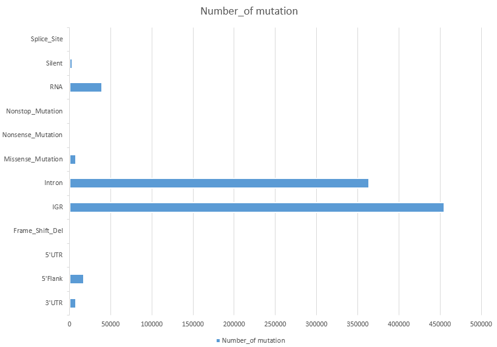

```python
Mutation_type
```

#### 2.2.6 Mutation distribution in significant genes calculated by MutSig

```python
MutSig_dis
```

[interactive chart not shown]

#### 2.2.7 The distribution of mutation shared by 5 samples

```python
OVMut_dis
```

[interactive chart not shown]

#### 2.2.8 Mutation distribution in most frequently mutated genes(top20)

```python
Mutatation_on_CRC_mmG
```

[interactive chart not shown]

### 2.3 Correlation analysis of genomic features and mutation density

#### 2.3.1 Download data.

From this [paper](https://www.ncbi.nlm.nih.gov/pmc/articles/PMC3816225/), we know what kind of cell-line is related to CRC.

From this [paper](https://www.ncbi.nlm.nih.gov/pmc/articles/PMC4280484/), we know what kind of genomic features affecting the mutation rate in cancer genomes.

So, here I decided to pick the features of GC content and histone modification to analysis the correlation with mutation density.

**Caco2_H3K27me3:** `wget http://hgdownload.cse.ucsc.edu/goldenPath/hg19/encodeDCC/wgEncodeUwHistone/wgEncodeUwHistoneCaco2H3k27me3StdRawDataRep1.fastq.gz`

**Caco2_H3K36me3:** `wget http://hgdownload.cse.ucsc.edu/goldenPath/hg19/encodeDCC/wgEncodeUwHistone/wgEncodeUwHistoneCaco2H3k36me3StdRawDataRep1.fastq.gz`

**Caco2_H3K4me3:** `wget http://hgdownload.cse.ucsc.edu/goldenPath/hg19/encodeDCC/wgEncodeUwHistone/wgEncodeUwHistoneCaco2H3k4me3StdRawDataRep1.fastq.gz`

**Hct116_H3K27ac:** `wget http://hgdownload.cse.ucsc.edu/goldenPath/hg19/encodeDCC/wgEncodeSydhHistone/wgEncodeSydhHistoneHct116H3k27acUcdRawDataRep1.fastq.tgz`

**Hct116_H3K27ac:** `wget http://hgdownload.cse.ucsc.edu/goldenPath/hg19/encodeDCC/wgEncodeSydhHistone/wgEncodeSydhHistoneHct116H3k27acUcdRawDataRep2.fastq.tgz`

**Hct116_H3K4me1:** `wget http://hgdownload.cse.ucsc.edu/goldenPath/hg19/encodeDCC/wgEncodeSydhHistone/wgEncodeSydhHistoneHct116H3k04me1UcdRawDataRep1.fastq.tgz`

**Dnase peaks in Caco2:** `wget http://hgdownload.cse.ucsc.edu/goldenPath/hg19/encodeDCC/wgEncodeAwgDnaseUniform/wgEncodeAwgDnaseUwCaco2UniPk.narrowPeak.gz`

**Dnase peaks in Hct116:** `wget http://hgdownload.cse.ucsc.edu/goldenPath/hg19/encodeDCC/wgEncodeAwgDnaseUniform/wgEncodeAwgDnaseUwHct116UniPk.narrowPeak.gz`

**Genome reference:** `wget ftp://ftp.sanger.ac.uk/pub/gencode/Gencode_human/release_19/GRCh37.p13.genome.fa.gz`

**Genome annotation file:** `wget ftp://ftp.sanger.ac.uk/pub/gencode/Gencode_human/release_19/gencode.v19.annotation.gtf.gz`

#### 2.3.2 Data analysis

From this [paper](https://www.ncbi.nlm.nih.gov/pmc/articles/PMC4405175/), we know how to analysis the data. Basically, it can be conclude as:

- We mapped chip-Seq reads on hg19 reference.
- The mutation densities is determined for all possible types of mutations by counting different types of mutations in 1 Mb windows and normalizing for the sequence composition of each window.( Example, In 1 Mb region , Number of G->A mutation is N1, number of G in this 1 Mb region is N2. So N1/N2 is the mutation density of 'G->A' in this region)
- For histone modifications, we calculated RPKM values of each histonme for 1 Mb windows along the genome from chip-seq data.
- We calculated GC content for 1 Mb windows along the genome.
- We calculated the average number of DNaseI hypersensitivity peaks overlapping 1 Mb windows.

#### 2.3.3 Correlation result

- Correlation of mutant density and DNaseI activity:

`cor.test(scale(Mut.density),scale(DNaseI activity),method="spearman")`

- Correlation of mutant density and GC content:

`cor.test(scale(Mut.density),GC content)`

- Correlation of mutant density and H3k4me1:

`cor.test(scale(Mut.density),scale(RPKM value of H3k4me1),method="spearman")`

- Correlation of mutant density and H3k27ac:

`cor.test(scale(Mut.density),scale(RPKM value of H3k27ac),method="spearman")`

- Correlation of mutant density and H3k27me3:

`cor.test(scale(Mut.density),scale(RPKM value of H3k27me3),method="spearman")`

- Correlation of mutant density and H3k36me3:

`cor.test(scale(Mut.density),scale(RPKM value of H3k36me3),method="spearman")`

- Correlation of mutant density and H3k4me3:

`cor.test(scale(Mut.density),scale(RPKM value of H3k4me3),method="spearman")`

**According the type of mutant, we did the correlation analysis on Chromosome 1.**

```python
COR
```

[interactive chart not shown]

**Conclusion**:

From the correlation analysis, It seems that histone modification(H3K4me1 H3K4me3 H3K27ac H3K27me3 H3K36me3) and DNase1 activity didn't correlated well with the mutant density.

But for the GC content, the higher of GC level correlated well with the hypermutation density of "G->A","G->T","A->G"(mutation density had been normalized for the sequence composition of each window)

### About "How would you figure out whether the biases you identified are biological or technical artifacts?"

It is a diffcult question for me to answer now. All I can do is:

1. Improve the analysis accuracy just like "1.3 How to improve accuracy of analysis" did.
2. Check detail distribution and did the statstic analysis(whether it is significant)
3. Find papers to support my hypothesis